# Preregistered Analysis of H1 to H8

- Show All Code
- Hide All Code
- View Source

Run on one simulated data set

Published

October 15, 2026

## About this document

This document runs the preregistered analysis of the study on **one simulated data set**. The simulated data look like the survey export, so every step of the analysis can be checked before data collection. The effects in the simulated data were set by hand. They are **not predictions**, and every result below only shows that the code works. For the real data, the simulation in the next section is replaced by reading in the survey export.

**Design.** The study crossed two factors. Participants either received negative feedback about the carbon footprint of the company they voted for or received no feedback. Independently, half of them were asked about their anticipated emotions right before they decided whether to keep or donate a possible $25 bonus.

| Cell | Feedback | Asked about anticipated emotions | Part | Participants after exclusions |
| --- | --- | --- | --- | --- |
| 1 | None | No | Replication | 798 |
| 2 | Negative | No | Replication | 798 |
| 3 | None | Yes | Extension | 532 |
| 4 | Negative | Yes | Extension | 532 |

The **replication part** followed the procedure of Hurst and Sintov (2022, Study 2). The **extension part** added the questions about anticipated emotions.

**Decision rules.** Every hypothesis has two one-sided tests at an alpha level of .05, read from the 90% confidence interval. The first asks whether the effect exists in the predicted direction. The second asks whether it is significantly smaller than a limit set in advance. Each limit carries the sign of the predicted effect. For guilt the limit is d = 0.155 and for donation d = −0.189, the effects the original study had a 33% chance of detecting, and for the other tests it is d = 0.20 or d = −0.20. An effect is significantly smaller than its limit when the whole 90% confidence interval lies on the side of the limit that is closer to zero, for example above d = −0.189 for the drop in donation. All effects are reported as Cohen’s *d*. Every model controls for environmental self-identity, gender, age, political orientation and education.

## 1. Simulated data

The simulation creates 2,660 valid participants plus 120 who fail the bot check and 14 duplicate Prolific IDs, so that the exclusions can be tested. For each person it first creates hidden “true” values and then turns them into answers on the real scales of the questionnaire.

- **Environmental self-identity** is random.
- **Guilt** rises strongly after negative feedback, and more so in people with a stronger identity.
- **Pride** falls after negative feedback.
- **Intentions** depend on identity only. Feedback has no effect on them.
- **Anticipated emotions** shift toward keeping the bonus after negative feedback and in people who feel more guilt.
- **Donation** becomes less likely after negative feedback and when keeping feels better, and more likely with more guilt and a stronger identity.

```r
set.seed(20261015)
kept  <- c(798, 798, 532, 532)             # planned participants after exclusions
n_bot <- c(36, 36, 24, 24)                 # simulated failures of the bot check
n_dup <- c(4, 4, 3, 3)                     # simulated duplicate submissions
cell <- rep(1:4, kept + n_bot + n_dup)
N <- length(cell)
type <- rep(rep(c("ok", "bot", "dup"), 4), times = as.vector(rbind(kept, n_bot, n_dup)))
feedback <- as.integer(cell %in% c(2, 4)); asked <- as.integer(cell %in% c(3, 4))
raw <- data.frame(id = sprintf("P%05d", seq_len(N)), cell = cell,
                  submitdate = as.POSIXct("2026-11-02 09:00", tz = "UTC") + sort(runif(N, 0, 6e5))[sample(N)])
raw$tyler <- ifelse(type == "bot", "arm", "leg")
dup_rows <- which(type == "dup"); src <- sample(which(type == "ok"), length(dup_rows))
raw$id[dup_rows] <- raw$id[src]; raw$submitdate[dup_rows] <- raw$submitdate[src] + 3600
raw$gender    <- sample(1:3, N, TRUE, c(.48, .49, .03))      # 1 man, 2 woman, 3 another gender
raw$birthyear <- 2026 - round(pmin(80, pmax(18, rnorm(N, 38, 13))))
raw$pol       <- sample(1:7, N, TRUE)                         # 1 very liberal ... 7 very conservative
raw$edu       <- sample(1:6, N, TRUE, c(.02, .25, .22, .12, .27, .12))
E  <- rnorm(N)                                                   # identity (hidden)
ee <- mvrnorm(N, c(0, 0), matrix(c(1, -.3, -.3, 1), 2))
G  <- 1.31 * feedback + .35 * E + .25 * feedback * E + ee[, 1]   # guilt (hidden)
P  <- -1.29 * feedback - .20 * E + ee[, 2]                       # pride (hidden)
I  <- .30 * E + rnorm(N, 0, sqrt(.91))                           # intentions (hidden)
A  <- .15 * feedback + .20 * as.numeric(scale(G)) - .25 * E +    # keeping feels better (hidden)
      rnorm(N, 0, sqrt(.88))
item <- function(m, lo, hi) round(pmin(hi, pmax(lo, m)))         # answer on a rating scale
for (j in 1:3)  raw[[paste0("eid", j)]]   <- item(5 + 1.1 * E + rnorm(N, 0, .7), 1, 7)
for (j in 1:3)  raw[[paste0("guilt", j)]] <- item(1.6 + .8 * G + rnorm(N, 0, .5), 1, 5)
for (j in 1:3)  raw[[paste0("pride", j)]] <- item(3.0 + .8 * P + rnorm(N, 0, .5), 1, 5)
for (j in 1:15) raw[[paste0("pei", j)]]   <- item(3.0 + .6 * I + rnorm(N, 0, .9), 1, 5)
raw$att_item <- ifelse(runif(N) < .03, sample(c(1, 2, 4, 5), N, TRUE), 3)
raw$keep_first <- ifelse(asked == 1, rbinom(N, 1, .5), NA)          # random order of the two blocks
for (j in 1:3) {                                                 # extension part only
  raw[[paste0("ap_keep", j)]] <- ifelse(asked == 1, item(2.8 + .5 * A + rnorm(N, 0, .45), 1, 5), NA)
  raw[[paste0("ag_keep", j)]] <- ifelse(asked == 1, item(2.0 - .4 * A + rnorm(N, 0, .45), 1, 5), NA)
  raw[[paste0("ap_don", j)]]  <- ifelse(asked == 1, item(3.4 - .5 * A + rnorm(N, 0, .45), 1, 5), NA)
  raw[[paste0("ag_don", j)]]  <- ifelse(asked == 1, item(1.5 + .4 * A + rnorm(N, 0, .45), 1, 5), NA)
}
lp <- -0.35 - 0.85 * feedback + .45 * as.numeric(scale(G)) - .45 * as.numeric(scale(A)) + .70 * E
raw$donate <- rbinom(N, 1, plogis(lp))                           # 1 = donate, 0 = keep
rm(E, ee, G, P, I, A, lp, type, dup_rows, src, feedback, asked, cell)
```

The hidden values are deleted at the end, so the analysis works only with what a real export would contain.

**Codebook of the export**

| Variable | Meaning |
| --- | --- |
| `id` | Prolific ID |
| `cell` | 1 to 4, as in the design table |
| `submitdate` | time of submission |
| `tyler` | answer to “Tyler fell and broke his leg, what did Tyler break?” (bot check, before the feedback; correct = “leg”) |
| `gender` | 1 = man, 2 = woman, 3 = another gender |
| `birthyear`, `pol`, `edu` | year of birth, political orientation (1 = very liberal to 7 = very conservative), education (1 to 6) |
| `eid1`–`eid3` | environmental self-identity, 1 to 7 |
| `guilt1`–`guilt3` | experienced guilt (guilty, remorseful, regretful), 1 to 5 |
| `pride1`–`pride3` | experienced pride (proud, pleased with myself, content), 1 to 5 |
| `pei1`–`pei15` | pro-environmental intentions for the coming week, 1 to 5 |
| `att_item` | instructed item in the intention scale (“please select ‘sometimes’”, correct = 3) |
| `ap_keep1`–`3`, `ag_keep1`–`3` | anticipated pride and guilt if keeping the bonus, 1 to 5 (extension part) |
| `ap_don1`–`3`, `ag_don1`–`3` | anticipated pride and guilt if donating the bonus, 1 to 5 (extension part) |
| `keep_first` | order of the two anticipated-emotion blocks, 1 = keeping first, 0 = donating first (extension part, assigned at random) |
| `donate` | 1 = donate, 0 = keep the bonus |

## 2. Exclusions and scores

Only checks that come **before the feedback** lead to exclusion, namely a wrong answer to the bot check and a repeated Prolific ID (the first submission is kept). An answer to the bot check counts as correct if it contains the word leg or legs, whatever else it contains, for example “Leg.” or “his leg”. The instructed item comes after the feedback, so it is used only in a robustness check.

```r
raw <- raw[order(raw$submitdate), ]
raw$excl_bot <- !grepl("\\blegs?\\b", raw$tyler, ignore.case = TRUE)   # passes: "leg", "Leg.", "his leg", "legs"
raw$excl_dup <- duplicated(raw$id)
kable(rbind(Started            = table(raw$cell),
            `Failed bot check` = tapply(raw$excl_bot, raw$cell, sum),
            `Duplicate ID`     = tapply(raw$excl_dup & !raw$excl_bot, raw$cell, sum),
            Kept               = tapply(!raw$excl_bot & !raw$excl_dup, raw$cell, sum)),
      caption = "Participants per cell")
```

Participants per cell

|  | 1 | 2 | 3 | 4 |
| --- | --- | --- | --- | --- |
| Started | 838 | 838 | 559 | 559 |
| Failed bot check | 36 | 36 | 24 | 24 |
| Duplicate ID | 4 | 4 | 3 | 3 |
| Kept | 798 | 798 | 532 | 532 |

Each scale is scored as the mean of its items. The **anticipated-emotions score** combines the four anticipated scales into one number, (pride − guilt for keeping) − (pride − guilt for donating). A higher score means that keeping the bonus is expected to feel better relative to donating it.

```r
d0 <- raw[!raw$excl_bot & !raw$excl_dup, ]
d0$feedback <- as.integer(d0$cell %in% c(2, 4))      # 0 = none, 1 = negative
d0$asked    <- as.integer(d0$cell %in% c(3, 4))      # 0 = replication, 1 = extension
d0$woman    <- as.integer(d0$gender == 2)
d0$age      <- 2026 - d0$birthyear
mean_of <- function(stem, k) rowMeans(d0[, paste0(stem, 1:k)])
d0$eid   <- mean_of("eid", 3);   d0$guilt <- mean_of("guilt", 3)
d0$pride <- mean_of("pride", 3); d0$pei   <- mean_of("pei", 15)
d0$ap_keep <- mean_of("ap_keep", 3); d0$ag_keep <- mean_of("ag_keep", 3)
d0$ap_don  <- mean_of("ap_don", 3);  d0$ag_don  <- mean_of("ag_don", 3)
d0$score   <- (d0$ap_keep - d0$ag_keep) - (d0$ap_don - d0$ag_don)
d0$att_fail <- d0$att_item != 3

alpha <- function(items) {                            # Cronbach's alpha
  k <- ncol(items); v <- var(items, use = "complete.obs")
  k / (k - 1) * (1 - sum(diag(v)) / sum(v))
}
scale_names <- c("eid", "guilt", "pride", "ap_keep", "ag_keep", "ap_don", "ag_don")
kable(data.frame(Scale = c(scale_names, "pei"),
                 Items = c(rep(3, 7), 15),
                 alpha = round(c(sapply(scale_names, function(s) alpha(d0[, paste0(s, 1:3)])),
                                 alpha(d0[, paste0("pei", 1:15)])), 2)),
      caption = "Reliability (Cronbach's alpha)")
```

Reliability (Cronbach’s alpha)

|  | Scale | Items | alpha |
| --- | --- | --- | --- |
| eid | eid | 3 | 0.86 |
| guilt | guilt | 3 | 0.91 |
| pride | pride | 3 | 0.89 |
| ap_keep | ap_keep | 3 | 0.71 |
| ag_keep | ag_keep | 3 | 0.57 |
| ap_don | ap_don | 3 | 0.70 |
| ag_don | ag_don | 3 | 0.60 |
|  | pei | 15 | 0.85 |

## 3. Analysis samples

H1 and H5 use **all participants**, because guilt and intentions were measured before anyone was asked about anticipated emotions. H2 to H4 use the **replication part**, because in the extension part the question about anticipated emotions came before the choice and could change it. H6 to H8 use the **extension part**, the only participants with anticipated emotions. The order of the two blocks of anticipated-emotion items (keeping first or donating first) was assigned at random, and the models of H6 to H8 also control for it.

```r
z <- function(v) as.numeric(scale(v))
fb_label <- function(x) factor(ifelse(x == 1, "Negative feedback", "No feedback"),
                               levels = c("No feedback", "Negative feedback"))
dat <- d0; d12 <- d0[d0$asked == 0, ]; d34 <- d0[d0$asked == 1, ]
for (nm in c("dat", "d12", "d34")) {                 # z-scores within each sample
  x <- base::get(nm)
  x$eid_z <- z(x$eid); x$guilt_z <- z(x$guilt); x$pride_z <- z(x$pride); x$pei_z <- z(x$pei)
  if (nm == "d34") x$score_z <- z(x$score)
  x$fb <- fb_label(x$feedback)
  assign(nm, x)
}
covs <- "eid_z + woman + age + pol + edu"
cov_names <- c("eid_z", "woman", "age", "pol", "edu")
covs34 <- paste(covs, "+ keep_first")                # extension part: also the order of the two blocks
cov_names34 <- c(cov_names, "keep_first")
kable(data.frame(Sample = c("All participants", "Replication part", "Extension part"),
                 N = c(nrow(dat), nrow(d12), nrow(d34))))
```

| Sample | N |
| --- | --- |
| All participants | 2660 |
| Replication part | 1596 |
| Extension part | 1064 |

**Show the helper functions (estimates, decisions, figures)**

```r
# Estimates as Cohen's d with 90% and 95% CIs. dir = predicted sign; limit = limit of the rule.
to_d <- function(v) oddsratio_to_d(v, log = TRUE)
row_lin <- function(H, claim, fit, term, rule, dir, limit) {      # linear model, z-scored outcome
  ci <- function(l) confint(fit, term, l)
  data.frame(H, claim, n = nobs(fit), rule, dir, limit, est = coef(fit)[[term]],
             lo90 = ci(.90)[1], hi90 = ci(.90)[2], lo95 = ci(.95)[1], hi95 = ci(.95)[2])
}
row_log <- function(H, claim, fit, term, rule, dir, limit) {      # logistic model, log-odds to d
  ci <- function(l) to_d(confint.default(fit, term, l))
  data.frame(H, claim, n = nobs(fit), rule, dir, limit, est = to_d(coef(fit)[[term]]),
             lo90 = ci(.90)[1], hi90 = ci(.90)[2], lo95 = ci(.95)[1], hi95 = ci(.95)[2])
}
row_path <- function(H, claim, point, draws, n, dir) {            # path: estimate and bootstrap draws
  q <- quantile(draws, c(.05, .95, .025, .975))                   # percentile intervals, as in PROCESS
  data.frame(H, claim, n, rule = "path", dir, limit = NA, est = to_d(point),
             lo90 = to_d(q[1]), hi90 = to_d(q[2]), lo95 = to_d(q[3]), hi95 = to_d(q[4]))
}
# Decision for one row. For paths, 'links' are the rows of its two links.
decide <- function(r, links = NULL) {
  r$found <- if (r$dir > 0) r$lo90 > 0 else r$hi90 < 0
  r$smaller <- if (r$rule == "path") any(sapply(links, function(l) l$smaller)) else
               if (r$dir > 0) r$hi90 < r$limit else r$lo90 > -r$limit
  r$verdict <- switch(r$rule,
    equivalence = if (r$lo90 > -r$limit && r$hi90 < r$limit) "supported" else
                  if (r$lo95 > 0 || r$hi95 < 0) "not supported" else "inconclusive",
    replication = if (r$found) "supported" else if (r$smaller) "not supported" else "inconclusive",
    if (r$smaller) "not supported" else if (r$found) "supported" else "inconclusive")
  r
}
show_result <- function(...) {                                    # small result table
  r <- rbind(...)
  kable(data.frame(Test = paste(r$H, r$claim), N = r$n, d = sprintf("%.2f", r$est),
                   `90% CI` = sprintf("[%.2f, %.2f]", r$lo90, r$hi90),
                   `95% CI` = sprintf("[%.2f, %.2f]", r$lo95, r$hi95),
                   Limit = ifelse(is.na(r$limit), "", ifelse(r$rule == "equivalence",
                                   sprintf("-%.3f to %.3f", r$limit, r$limit), sprintf("%.3f", r$dir * r$limit))),
                   Verdict = r$verdict, check.names = FALSE))
}

# Figures: autumn palette and a common look.
autumn <- c(rust = "#A63D1E", orange = "#D9822B", gold = "#E3A33B",
            olive = "#6B7F3A", brown = "#5C3A21", plum = "#7A3B4F")
fb_cols <- c("No feedback" = autumn[["gold"]], "Negative feedback" = autumn[["rust"]])
theme_set(theme_minimal(base_size = 12) +
          theme(plot.title = element_text(face = "bold", colour = "black"), text = element_text(colour = "black"),
                axis.text = element_text(colour = "black"),
                legend.position = "bottom", panel.grid.minor = element_blank()))
mean_ci <- function(df, y, g) {                       # mean and 95% CI of y per group
  do.call(rbind, lapply(split(df[[y]], df[[g]]), function(v) {
    m <- mean(v); se <- sd(v) / sqrt(length(v))
    data.frame(m = m, lo = m - 1.96 * se, hi = m + 1.96 * se)
  })) |> transform(group = levels(df[[g]]))
}
means_plot <- function(df, y, ylab, title, lims) {    # each participant plus group means with 95% CI
  mc <- mean_ci(df, y, "fb")
  ggplot(df, aes(fb, .data[[y]], colour = fb)) +
    geom_jitter(width = .25, height = .05, alpha = .15, size = .9) +
    geom_errorbar(data = mc, aes(x = group, ymin = lo, ymax = hi), inherit.aes = FALSE,
                  width = .12, linewidth = .9, colour = autumn[["brown"]]) +
    geom_point(data = mc, aes(x = group, y = m), inherit.aes = FALSE, size = 3.5,
               colour = autumn[["brown"]]) +
    scale_colour_manual(values = fb_cols, guide = "none") +
    coord_cartesian(ylim = lims) + labs(x = NULL, y = ylab, title = title)
}
choice_plot <- function(df, x, xlab, title) {         # predictor for those who kept and those who donated
  df$choice <- factor(ifelse(df$donate == 1, "Donated", "Kept the bonus"), levels = c("Kept the bonus", "Donated"))
  ggplot(df, aes(choice, .data[[x]], fill = fb)) +
    geom_violin(position = position_dodge(.8), width = .75, alpha = .35, colour = NA) +
    geom_boxplot(position = position_dodge(.8), width = .18, outlier.shape = NA, alpha = .9) +
    scale_fill_manual(values = fb_cols, name = NULL) +
    labs(x = "Choice", y = xlab, title = title)
}
choice_bars <- function(df, g, title) {               # share who kept and who donated per group
  df$choice <- factor(ifelse(df$donate == 1, "Donated", "Kept the bonus"), levels = c("Kept the bonus", "Donated"))
  tab <- as.data.frame(prop.table(table(group = df[[g]], choice = df$choice), 1))
  ggplot(tab, aes(group, Freq, fill = choice)) +
    geom_col(width = .6, alpha = .9) +
    geom_text(aes(label = scales::percent(Freq, 1)), position = position_stack(vjust = .5), colour = "white",
              fontface = "bold") +
    scale_fill_manual(values = c("Kept the bonus" = autumn[["olive"]], "Donated" = autumn[["orange"]]), name = NULL) +
    scale_y_continuous(labels = scales::percent) +
    labs(x = NULL, y = "Share of participants", title = title)
}
```

# Replication of Hurst and Sintov (2022)

## H1. Negative feedback raises experienced guilt

The first test checks whether the feedback worked as in the original study. A linear regression predicts guilt (z-scored) from feedback in all participants, controlling for whether they were asked about anticipated emotions. The effect counts as **supported** if guilt is higher after negative feedback and as **not supported** if the effect is significantly smaller than d = 0.155. The other results on donation are interpreted only if H1 is supported.

```r
f1 <- lm(as.formula(paste("guilt_z ~ feedback + asked +", covs)), data = dat)
r1 <- decide(row_lin("H1", "feedback raises guilt", f1, "feedback", "replication", 1, .155))
show_result(r1)
```

| Test | N | d | 90% CI | 95% CI | Limit | Verdict |
| --- | --- | --- | --- | --- | --- | --- |
| H1 feedback raises guilt | 2660 | 1.03 | [0.98, 1.08] | [0.97, 1.09] | 0.155 | supported |

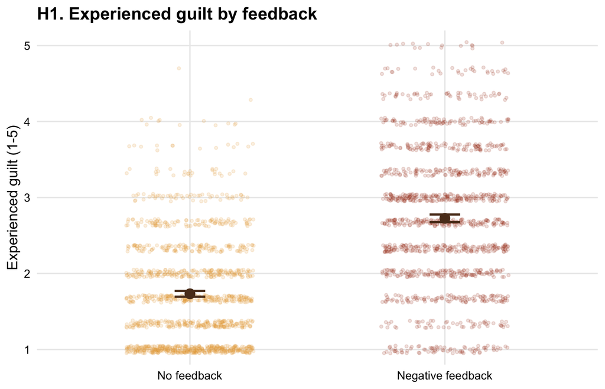

```r
means_plot(dat, "guilt", "Experienced guilt (1-5)", "H1. Experienced guilt by feedback", c(1, 5))
```

Each dot is one participant, and the brown point shows the mean with its 95% confidence interval. **Verdict: supported.**

## H2. Negative feedback lowers donation

A logistic regression predicts the choice to donate from feedback in the replication part. The effect counts as **supported** if donation is lower after negative feedback. It counts as **not supported** if the drop is significantly smaller than d = −0.189, that is, if the whole 90% confidence interval lies above −0.189, which would agree with Hurst and Sintov’s report of no total effect.

```r
f2 <- glm(as.formula(paste("donate ~ feedback +", covs)), binomial, data = d12)
r2 <- decide(row_log("H2", "feedback lowers donation", f2, "feedback", "replication", -1, .189))
if (r1$verdict != "supported") r2$verdict <- paste(r2$verdict, "(not interpreted: H1 not supported)")
show_result(r2)
```

| Test | N | d | 90% CI | 95% CI | Limit | Verdict |
| --- | --- | --- | --- | --- | --- | --- |
| H2 feedback lowers donation | 1596 | -0.35 | [-0.45, -0.24] | [-0.47, -0.22] | -0.189 | supported |

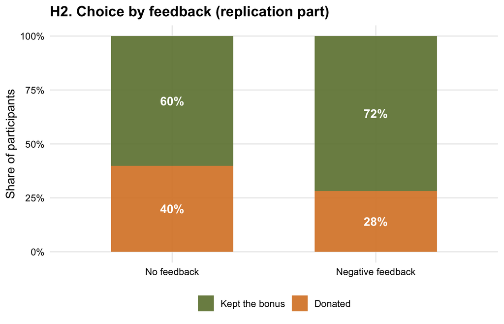

```r
choice_bars(d12, "fb", "H2. Choice by feedback (replication part)")
```

Each bar splits one feedback group into those who kept the bonus and those who donated. **Verdict: supported.**

## H3. Participants who feel more guilt donate more often

A mediation analysis (PROCESS model 4, 5,000 bootstrap samples) places guilt and pride between feedback and donation in the replication part. H3 concerns the path through guilt. It has two links, from feedback to guilt and from guilt to donation. The path counts as **supported** if its 90% bootstrap interval lies above zero and as **not supported** if either link is significantly smaller than d = 0.20. The second link is an association, because guilt was measured and not assigned.

```r
f3a <- lm(as.formula(paste("guilt_z ~ feedback +", covs)), data = d12)                  # link 1
f3y <- glm(as.formula(paste("donate ~ feedback + guilt_z + pride_z +", covs)),          # link 2 and H4
           binomial, data = d12)
p3 <- process(data = d12, y = "donate", x = "feedback", m = c("guilt", "pride"), cov = cov_names,
              model = 4, boot = 5000, seed = boot_seed, conf = 90, save = 1, progress = 0, outscreen = 0)
ind3 <- p3$guilt_feedback * p3$donate_guilt                 # bootstrap draws of the path through guilt
# Point estimate from the same models in the original sample (PROCESS reports this one,
# not the mean of the bootstrap draws). Mediators in raw units, as in PROCESS.
a3 <- coef(lm(as.formula(paste("guilt ~ feedback +", covs)), data = d12))[["feedback"]]
b3 <- coef(glm(as.formula(paste("donate ~ feedback + guilt + pride +", covs)), binomial, data = d12))[["guilt"]]
r3a <- decide(row_lin("H3 link 1", "feedback raises guilt", f3a, "feedback", "ours", 1, .20))
r3b <- decide(row_log("H3 link 2", "more guilt, more donation", f3y, "guilt_z", "ours", 1, .20))
r3  <- decide(row_path("H3", "path through guilt", a3 * b3, ind3, nobs(f3y), 1), list(r3a, r3b))
show_result(r3a, r3b, r3)
```

| Test | N | d | 90% CI | 95% CI | Limit | Verdict |
| --- | --- | --- | --- | --- | --- | --- |
| H3 link 1 feedback raises guilt | 1596 | 1.06 | [1.00, 1.13] | [0.99, 1.14] | 0.200 | supported |
| H3 link 2 more guilt, more donation | 1596 | 0.18 | [0.11, 0.25] | [0.10, 0.26] | 0.200 | supported |
| H3 path through guilt | 1596 | 0.19 | [0.12, 0.27] | [0.11, 0.28] |  | supported |

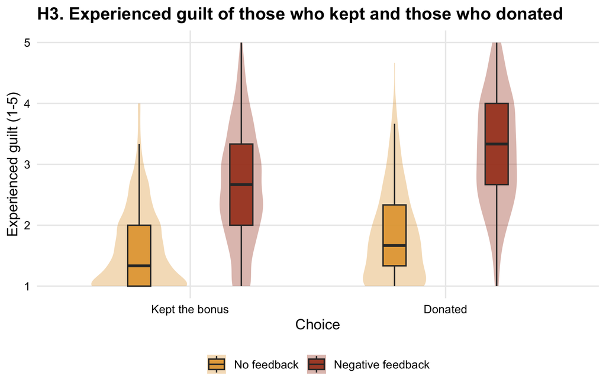

```r
choice_plot(d12, "guilt", "Experienced guilt (1-5)", "H3. Experienced guilt of those who kept and those who donated")
```

The figure compares the guilt of participants who kept the bonus with the guilt of those who donated, separately for the two feedback groups. The box marks the middle half of the scores and the line inside it the median. **Verdict: supported.**

## H4. Negative direct effect of feedback on donation

The same mediation model gives the direct effect of the feedback on donation, with guilt and pride held constant. Hurst and Sintov reported −0.68 in log odds (their Table 4). The effect counts as **supported** if it is negative and as **not supported** if it is significantly smaller than d = −0.20, that is, if the whole 90% confidence interval lies above −0.20.

```r
r4 <- decide(row_log("H4", "negative direct effect", f3y, "feedback", "ours", -1, .20))
show_result(r4)
```

| Test | N | d | 90% CI | 95% CI | Limit | Verdict |
| --- | --- | --- | --- | --- | --- | --- |
| H4 negative direct effect | 1596 | -0.58 | [-0.72, -0.44] | [-0.74, -0.41] | -0.200 | supported |

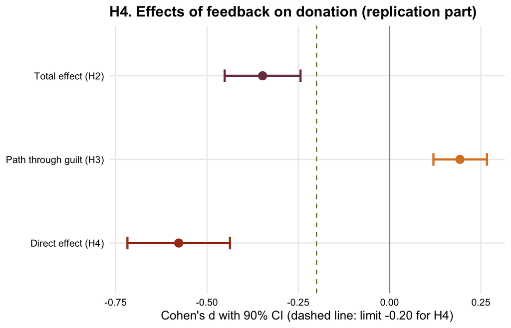

```r
eff4 <- data.frame(effect = c("Total effect (H2)", "Path through guilt (H3)", "Direct effect (H4)"),
                   est = c(r2$est, r3$est, r4$est), lo = c(r2$lo90, r3$lo90, r4$lo90),
                   hi = c(r2$hi90, r3$hi90, r4$hi90))
eff4$effect <- factor(eff4$effect, levels = rev(eff4$effect))
ggplot(eff4, aes(est, effect, colour = effect)) +
  geom_vline(xintercept = 0, colour = "grey60") +
  geom_vline(xintercept = -.20, linetype = "dashed", colour = autumn[["olive"]]) +
  geom_errorbar(aes(xmin = lo, xmax = hi), orientation = "y", width = .15, linewidth = 1) +
  geom_point(size = 3.5) +
  scale_colour_manual(values = unname(autumn[c("rust", "orange", "plum")]), guide = "none") +
  labs(x = "Cohen's d with 90% CI (dashed line: limit -0.20 for H4)", y = NULL,
       title = "H4. Effects of feedback on donation (replication part)")
```

The figure places the three effects side by side. The path through guilt raises donation, whereas the direct effect lowers it, and the total effect is the result of both. **Verdict: supported.**

## H5. Feedback leaves pro-environmental intentions unchanged

Hurst and Sintov found no total effect of the feedback on intentions. An equivalence test (Lakens et al., 2018) checks whether this absence holds. A linear regression predicts intentions (z-scored) from feedback in all participants. The absence of an effect counts as **supported** if the 90% confidence interval lies between d = −0.155 and 0.155, and as **not supported** if the 95% confidence interval excludes zero.

```r
f5 <- lm(as.formula(paste("pei_z ~ feedback + asked +", covs)), data = dat)
r5 <- decide(row_lin("H5", "no effect on intentions", f5, "feedback", "equivalence", 0, .155))
show_result(r5)
```

| Test | N | d | 90% CI | 95% CI | Limit | Verdict |
| --- | --- | --- | --- | --- | --- | --- |
| H5 no effect on intentions | 2660 | 0.03 | [-0.04, 0.09] | [-0.05, 0.10] | -0.155 to 0.155 | supported |

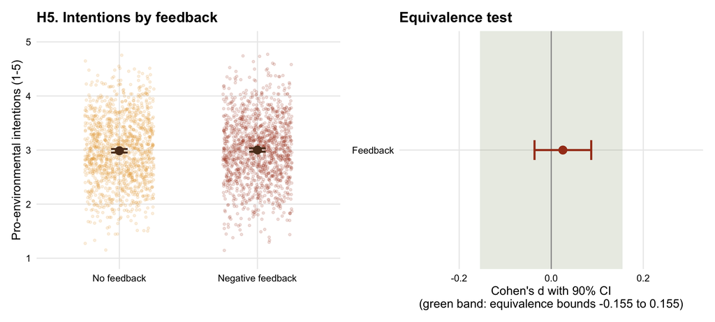

```r
means_plot(dat, "pei", "Pro-environmental intentions (1-5)", "H5. Intentions by feedback", c(1, 5)) +
  ggplot(r5, aes(est, "Feedback")) +
    annotate("rect", xmin = -.155, xmax = .155, ymin = -Inf, ymax = Inf, fill = autumn[["olive"]], alpha = .15) +
    geom_vline(xintercept = 0, colour = "grey60") +
    geom_errorbar(aes(xmin = lo90, xmax = hi90), orientation = "y", width = .1, linewidth = 1,
                  colour = autumn[["rust"]]) +
    geom_point(size = 3.5, colour = autumn[["rust"]]) + coord_cartesian(xlim = c(-.3, .3)) +
    labs(x = "Cohen's d with 90% CI\n(green band: equivalence bounds -0.155 to 0.155)", y = NULL,
         title = "Equivalence test")
```

The right panel shows the equivalence test. If the whole interval lies inside the green band, the effect is too small to matter. **Verdict: supported.**

# Extension: Anticipated Emotions

## H6. Negative feedback makes keeping feel better relative to donating

A linear regression predicts the anticipated-emotions score (z-scored) from feedback in the extension part. Feedback was assigned at random, so this test is causal. The effect counts as **supported** if the score is higher after negative feedback and as **not supported** if the shift is significantly smaller than d = 0.20, which includes no shift and a shift toward donating.

```r
f6 <- lm(as.formula(paste("score_z ~ feedback +", covs34)), data = d34)
r6 <- decide(row_lin("H6", "feedback raises the score", f6, "feedback", "ours", 1, .20))
show_result(r6)
```

| Test | N | d | 90% CI | 95% CI | Limit | Verdict |
| --- | --- | --- | --- | --- | --- | --- |
| H6 feedback raises the score | 1064 | 0.27 | [0.17, 0.37] | [0.15, 0.39] | 0.200 | supported |

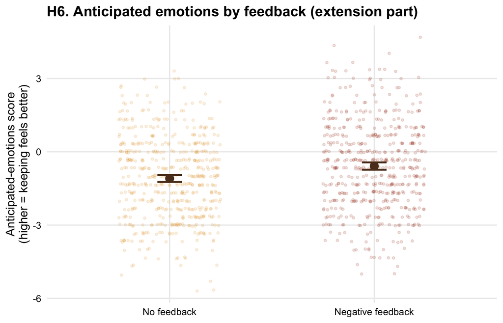

```r
means_plot(d34, "score", "Anticipated-emotions score\n(higher = keeping feels better)",
           "H6. Anticipated emotions by feedback (extension part)", range(d34$score))
```

**Verdict: supported.**

## H7. Participants who expect keeping to feel better donate less often

A logistic regression predicts donation from the anticipated-emotions score in the extension part, holding feedback, guilt and pride constant. This is an association, because anticipated emotions were measured and not assigned. The relation counts as **supported** if a higher score goes with less donation and as **not supported** if it is significantly weaker than d = −0.20 per standard deviation of the score, that is, if the whole 90% confidence interval lies above −0.20.

```r
f7 <- glm(as.formula(paste("donate ~ score_z + feedback + guilt_z + pride_z +", covs34)),
          binomial, data = d34)
r7 <- decide(row_log("H7", "higher score, less donation", f7, "score_z", "ours", -1, .20))
show_result(r7)
```

| Test | N | d | 90% CI | 95% CI | Limit | Verdict |
| --- | --- | --- | --- | --- | --- | --- |
| H7 higher score, less donation | 1064 | -0.23 | [-0.30, -0.16] | [-0.31, -0.15] | -0.200 | supported |

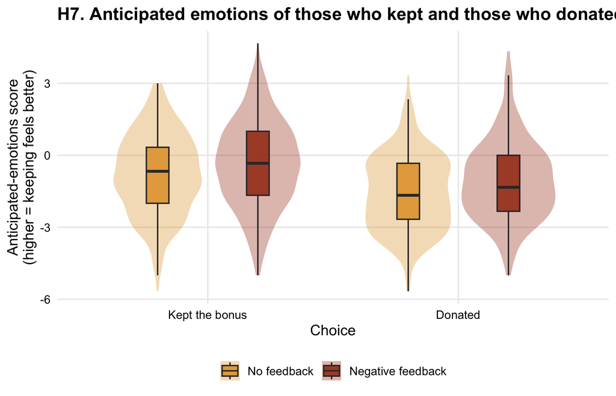

```r
choice_plot(d34, "score", "Anticipated-emotions score\n(higher = keeping feels better)",
            "H7. Anticipated emotions of those who kept and those who donated")
```

**Verdict: supported.**

## H8. Feedback lowers donation through anticipated emotions

A serial mediation analysis (PROCESS model 6, 5,000 bootstrap samples) places guilt and pride first and the anticipated-emotions score last between feedback and donation in the extension part. The model follows the feedback theory of emotion, in which the emotions that the feedback evokes can change the emotions people anticipate. Guilt and pride were measured at the same moment, so the model also lets guilt predict pride, but this order does not change H8. Feedback can reach the score directly or through guilt, pride, or both, and in every case the score then leads to donation. H8 concerns the sum of all paths that run through the score, the whole effect of the feedback on donation that passes through anticipated emotions. It counts as **supported** if its 90% bootstrap interval lies below zero and as **not supported** if H6 is significantly smaller than d = 0.20 or H7 significantly weaker than d = −0.20.

```r
p8 <- process(data = d34, y = "donate", x = "feedback", m = c("guilt", "pride", "score"), cov = cov_names34,
              model = 6, boot = 5000, seed = boot_seed, conf = 90, save = 1, progress = 0, outscreen = 0)
b_score  <- p8$donate_score                                           # score -> donation
path_a   <- p8$score_feedback * b_score                               # feedback -> score -> donation
path_ga  <- p8$guilt_feedback * p8$score_guilt * b_score              # feedback -> guilt -> score -> donation
path_pa  <- p8$pride_feedback * p8$score_pride * b_score              # feedback -> pride -> score -> donation
path_gpa <- p8$guilt_feedback * p8$pride_guilt * p8$score_pride * b_score  # feedback -> guilt -> pride -> score -> donation
path_g   <- p8$guilt_feedback * p8$donate_guilt                       # feedback -> guilt -> donation
ind8 <- path_a + path_ga + path_pa + path_gpa                         # everything that runs through the score
# Point estimates from the same models in the original sample, mediators in raw units.
cg <- coef(lm(as.formula(paste("guilt ~ feedback +", covs34)), data = d34))
cp <- coef(lm(as.formula(paste("pride ~ feedback + guilt +", covs34)), data = d34))
cs <- coef(lm(as.formula(paste("score ~ feedback + guilt + pride +", covs34)), data = d34))
cy <- coef(glm(as.formula(paste("donate ~ feedback + guilt + pride + score +", covs34)), binomial, data = d34))
pt <- c(a = cs[["feedback"]] * cy[["score"]],
        ga = cg[["feedback"]] * cs[["guilt"]] * cy[["score"]],
        pa = cp[["feedback"]] * cs[["pride"]] * cy[["score"]],
        gpa = cg[["feedback"]] * cp[["guilt"]] * cs[["pride"]] * cy[["score"]],
        g = cg[["feedback"]] * cy[["guilt"]])
pt8 <- sum(pt[c("a", "ga", "pa", "gpa")])
r8 <- decide(row_path("H8", "paths through the score", pt8, ind8, nrow(d34), -1), list(r6, r7))
show_result(r8)
```

| Test | N | d | 90% CI | 95% CI | Limit | Verdict |
| --- | --- | --- | --- | --- | --- | --- |
| H8 paths through the score | 1064 | -0.06 | [-0.09, -0.04] | [-0.10, -0.03] |  | supported |

```r
paths8 <- rbind(row_path("", "feedback -> score -> donation", pt[["a"]], path_a, nrow(d34), -1),
                row_path("", "feedback -> guilt -> score -> donation", pt[["ga"]], path_ga, nrow(d34), -1),
                row_path("", "feedback -> pride -> score -> donation", pt[["pa"]], path_pa, nrow(d34), -1),
                row_path("", "feedback -> guilt -> pride -> score -> donation", pt[["gpa"]], path_gpa, nrow(d34), -1),
                row_path("", "all paths through the score (H8)", pt8, ind8, nrow(d34), -1),
                row_path("", "feedback -> guilt -> donation", pt[["g"]], path_g, nrow(d34), 1))
kable(data.frame(Path = paths8$claim, d = sprintf("%.2f", paths8$est),
                 `90% CI` = sprintf("[%.2f, %.2f]", paths8$lo90, paths8$hi90), check.names = FALSE),
      caption = "Specific paths of the serial model")
```

Specific paths of the serial model

| Path | d | 90% CI |
| --- | --- | --- |
| feedback -> score -> donation | -0.04 | [-0.07, -0.01] |
| feedback -> guilt -> score -> donation | -0.02 | [-0.04, -0.01] |
| feedback -> pride -> score -> donation | -0.00 | [-0.01, 0.01] |
| feedback -> guilt -> pride -> score -> donation | -0.00 | [-0.00, 0.00] |
| all paths through the score (H8) | -0.06 | [-0.09, -0.04] |
| feedback -> guilt -> donation | 0.22 | [0.14, 0.31] |

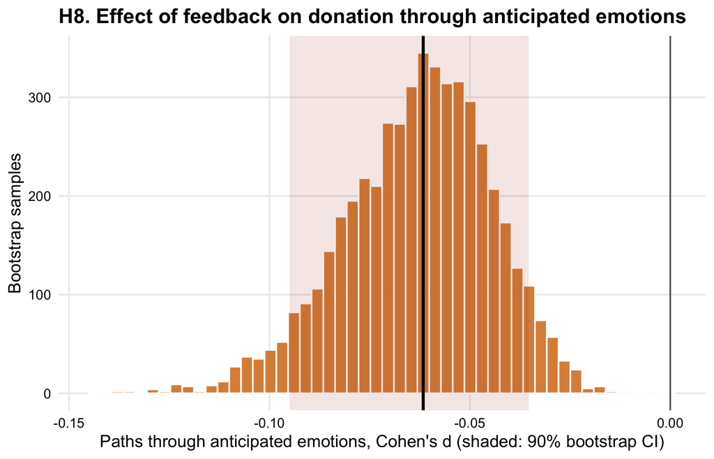

```r
b8 <- data.frame(d = to_d(ind8)); q8 <- quantile(b8$d, c(.05, .95))
ggplot(b8, aes(d)) +
  geom_histogram(bins = 50, fill = autumn[["orange"]], colour = "white", alpha = .9) +
  annotate("rect", xmin = q8[1], xmax = q8[2], ymin = -Inf, ymax = Inf, fill = autumn[["rust"]], alpha = .12) +
  geom_vline(xintercept = 0, colour = "grey40") +
  geom_vline(xintercept = to_d(pt8), colour = "black", linewidth = 1) +
  labs(x = "Paths through anticipated emotions, Cohen's d (shaded: 90% bootstrap CI)",
       y = "Bootstrap samples", title = "H8. Effect of feedback on donation through anticipated emotions")
```

The histogram shows the 5,000 bootstrap estimates of H8. If the shaded interval lies entirely left of zero, the effect through anticipated emotions is negative. **Verdict: supported.**

# Summary

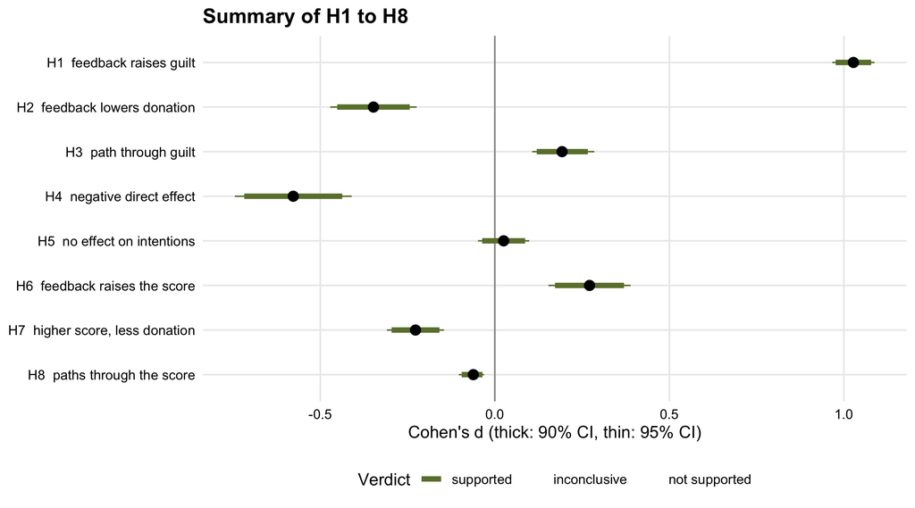

```r
stopifnot(f2$converged, f3y$converged, f7$converged)          # logistic models converged
res <- rbind(r1, r2, r3a, r3b, r3, r4, r5, r6, r7, r8)
expl <- all(c(r6$verdict, r7$verdict, r8$verdict) == "supported")
sm <- res[!grepl("link", res$H), ]
sm$label <- factor(paste(sm$H, sm$claim, sep = "  "), levels = rev(paste(sm$H, sm$claim, sep = "  ")))
sm$verdict_short <- factor(sub(" \\(.*", "", sm$verdict), levels = c("supported", "inconclusive", "not supported"))
verdict_cols <- c("supported" = autumn[["olive"]], "inconclusive" = autumn[["gold"]],
                  "not supported" = autumn[["rust"]])
ggplot(sm, aes(est, label, colour = verdict_short)) +
  geom_vline(xintercept = 0, colour = "grey60") +
  geom_errorbar(aes(xmin = lo95, xmax = hi95), orientation = "y", width = 0, linewidth = .5) +
  geom_errorbar(aes(xmin = lo90, xmax = hi90), orientation = "y", width = 0, linewidth = 1.8) +
  geom_point(size = 3, colour = "black") +
  scale_colour_manual(values = verdict_cols, name = "Verdict", drop = FALSE) +
  labs(x = "Cohen's d (thick: 90% CI, thin: 95% CI)", y = NULL, title = "Summary of H1 to H8")
```

```r
show_result(r1, r2, r3, r4, r5, r6, r7, r8)
```

| Test | N | d | 90% CI | 95% CI | Limit | Verdict |
| --- | --- | --- | --- | --- | --- | --- |
| H1 feedback raises guilt | 2660 | 1.03 | [0.98, 1.08] | [0.97, 1.09] | 0.155 | supported |
| H2 feedback lowers donation | 1596 | -0.35 | [-0.45, -0.24] | [-0.47, -0.22] | -0.189 | supported |
| H3 path through guilt | 1596 | 0.19 | [0.12, 0.27] | [0.11, 0.28] |  | supported |
| H4 negative direct effect | 1596 | -0.58 | [-0.72, -0.44] | [-0.74, -0.41] | -0.200 | supported |
| H5 no effect on intentions | 2660 | 0.03 | [-0.04, 0.09] | [-0.05, 0.10] | -0.155 to 0.155 | supported |
| H6 feedback raises the score | 1064 | 0.27 | [0.17, 0.37] | [0.15, 0.39] | 0.200 | supported |
| H7 higher score, less donation | 1064 | -0.23 | [-0.30, -0.16] | [-0.31, -0.15] | -0.200 | supported |
| H8 paths through the score | 1064 | -0.06 | [-0.09, -0.04] | [-0.10, -0.03] |  | supported |

The explanation by anticipated emotions counts as supported only if H6, H7 and H8 are all supported. **In these data, the explanation is supported.**

# Robustness Checks

These checks repeat key tests in other ways. They give estimates only, without decisions. The first repeats the drop in donation on all participants, controlling for whether they were asked about anticipated emotions. The other two repeat the drop in donation and the direct effect after excluding participants who failed the instructed item, as Hurst and Sintov did.

```r
f2_all <- glm(as.formula(paste("donate ~ feedback + asked +", covs)), binomial, data = dat)
d12_hs <- d12[!d12$att_fail, ]
f2_hs  <- glm(as.formula(paste("donate ~ feedback +", covs)), binomial, data = d12_hs)
f4_hs  <- glm(as.formula(paste("donate ~ feedback + guilt_z + pride_z +", covs)), binomial, data = d12_hs)
rob <- rbind(row_log("H2", "all participants, controlling for being asked", f2_all, "feedback", "", -1, NA),
             row_log("H2", "without failed instructed item", f2_hs, "feedback", "", -1, NA),
             row_log("H4", "without failed instructed item", f4_hs, "feedback", "", -1, NA))
kable(data.frame(Check = paste(rob$H, rob$claim), N = rob$n, d = sprintf("%.2f", rob$est),
                 `95% CI` = sprintf("[%.2f, %.2f]", rob$lo95, rob$hi95), check.names = FALSE))
```

| Check | N | d | 95% CI |
| --- | --- | --- | --- |
| H2 all participants, controlling for being asked | 2660 | -0.29 | [-0.39, -0.20] |
| H2 without failed instructed item | 1553 | -0.35 | [-0.48, -0.23] |
| H4 without failed instructed item | 1553 | -0.58 | [-0.75, -0.41] |

# Exploratory Analyses

These analyses were preregistered as exploratory. They give estimates with 95% confidence intervals and no decisions.

## Does environmental identity strengthen the effect of feedback on guilt?

```r
fE <- lm(guilt_z ~ feedback * eid_z + asked + woman + age + pol + edu, data = dat)
rE <- row_lin("E1", "identity x feedback on guilt", fE, "feedback:eid_z", "", 1, NA)
kable(data.frame(Effect = rE$claim, b = sprintf("%.2f", rE$est),
                 `95% CI` = sprintf("[%.2f, %.2f]", rE$lo95, rE$hi95), check.names = FALSE))
```

| Effect | b | 95% CI |
| --- | --- | --- |
| identity x feedback on guilt | 0.23 | [0.17, 0.29] |

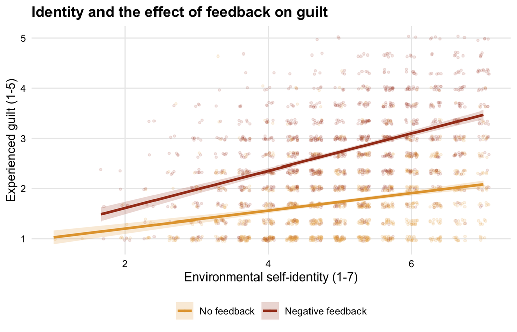

```r
ggplot(dat, aes(eid, guilt, colour = fb, fill = fb)) +
  geom_jitter(width = .08, height = .05, alpha = .12, size = .8) +
  geom_smooth(method = "lm", formula = y ~ x, linewidth = 1.2, alpha = .2) +
  scale_colour_manual(values = fb_cols, name = NULL) + scale_fill_manual(values = fb_cols, name = NULL) +
  labs(x = "Environmental self-identity (1-7)", y = "Experienced guilt (1-5)",
       title = "Identity and the effect of feedback on guilt")
```

If the lines move apart as identity rises, negative feedback raises guilt more in people with a stronger environmental identity.

## Does being asked about anticipated emotions change donation?

```r
fS <- glm(as.formula(paste("donate ~ asked + feedback +", covs)), binomial, data = dat)
fX <- glm(as.formula(paste("donate ~ feedback * asked +", covs)), binomial, data = dat)
rS <- rbind(row_log("E2", "being asked and donation", fS, "asked", "", 0, NA),
            row_log("E2", "feedback x being asked", fX, "feedback:asked", "", 0, NA))
kable(data.frame(Effect = rS$claim, d = sprintf("%.2f", rS$est),
                 `95% CI` = sprintf("[%.2f, %.2f]", rS$lo95, rS$hi95), check.names = FALSE))
```

| Effect | d | 95% CI |
| --- | --- | --- |
| being asked and donation | 0.02 | [-0.08, 0.12] |
| feedback x being asked | 0.16 | [-0.04, 0.35] |

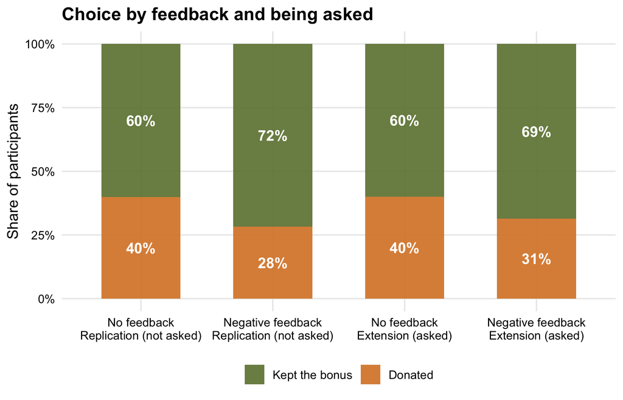

```r
dat$part <- factor(ifelse(dat$asked == 1, "Extension (asked)", "Replication (not asked)"),
                   levels = c("Replication (not asked)", "Extension (asked)"))
dat$group4 <- factor(paste(dat$fb, dat$part, sep = "\n"),
                     levels = paste(rep(levels(dat$fb), 2), rep(levels(dat$part), each = 2), sep = "\n"))
choice_bars(dat, "group4", "Choice by feedback and being asked")
```

## Did the order of the two blocks change anticipated emotions?

```r
fO <- lm(as.formula(paste("score_z ~ keep_first + feedback +", covs)), data = d34)
rO <- row_lin("E", "keeping rated first", fO, "keep_first", "", 0, NA)
kable(data.frame(Effect = "Keeping rated first (vs. donating first) on the score", d = sprintf("%.2f", rO$est),
                 `95% CI` = sprintf("[%.2f, %.2f]", rO$lo95, rO$hi95), check.names = FALSE))
```

| Effect | d | 95% CI |
| --- | --- | --- |
| Keeping rated first (vs. donating first) on the score | -0.05 | [-0.17, 0.07] |

## Does guilt change anticipated emotions?

The serial model of H8 also shows how guilt and anticipated emotions are related. The figure plots the anticipated-emotions score against guilt in the extension part. The path from feedback through guilt and then the score to donation is reported in the table of H8.

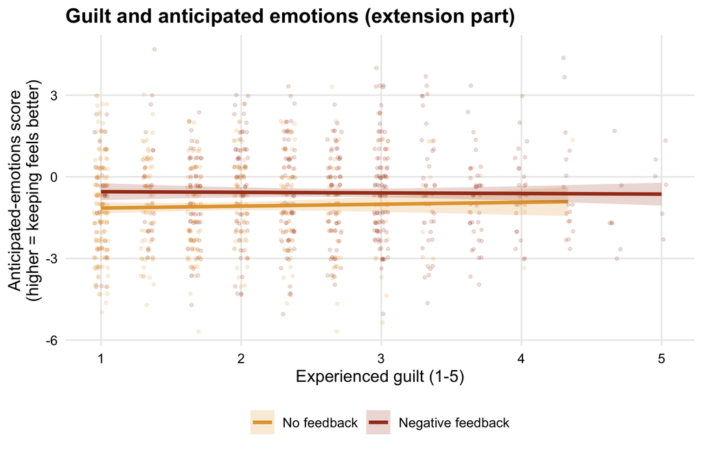

```r
ggplot(d34, aes(guilt, score, colour = fb, fill = fb)) +
  geom_jitter(width = .05, height = .05, alpha = .15, size = .8) +
  geom_smooth(method = "lm", formula = y ~ x, linewidth = 1.2, alpha = .2) +
  scale_colour_manual(values = fb_cols, name = NULL) + scale_fill_manual(values = fb_cols, name = NULL) +
  labs(x = "Experienced guilt (1-5)", y = "Anticipated-emotions score\n(higher = keeping feels better)",
       title = "Guilt and anticipated emotions (extension part)")
```